# Assignment 2 (A2): Language development in autistic and neurotypical children

## Discuss the differences in performance of your model in training and testing data. Is the modelany good?

The higher RMSE on the test data indicates that the model is likely overfit on the training data and does not generalize particularly well to new data. This is somewhat to be expected, however my best model is likely not good enough given how big of an error 1.1 is.

The error is rather large considering how small the value range is:

```r
data %>%
  group_by(Diagnosis)%>%
  summarize(
    mean_MLU = mean(CHI_MLU, na.rm = TRUE),
    max_MLU = max(CHI_MLU, na.rm = TRUE),
    min_MLU = min(CHI_MLU, na.rm = TRUE)
  )
```

```
## # A tibble: 2 × 4
##   Diagnosis mean_MLU max_MLU min_MLU
##   <fct>        <dbl>   <dbl>   <dbl>
## 1 TD            2.31    4.36   0.558
## 2 ASD           1.64    4.30   0
```

Show how ASD child fare in Child MLU compared to the average TD child at each visit

```r
model <- readRDS("data/model4_fit.rds")
model_data <- model$data

#the mean is being based on the TD mean, "the average TD child at each visit"
td_mean_data <- model_data %>%
  subset(Diagnosis == "TD")%>%
  group_by(Visit) %>%
  summarize(Mean_CHI_MLU = mean(CHI_MLU))

asd_mean_data <- model_data %>%
  subset(Diagnosis == "ASD")%>%
  group_by(Visit) %>%
  summarize(Mean_CHI_MLU = mean(CHI_MLU))

#adding low and high functioning for the sake of the plot
model_data <- model_data %>%
  left_join(td_mean_data, by = "Visit") %>%
  mutate(functioning = ifelse(CHI_MLU >= Mean_CHI_MLU, "high", "low"))

asd_data <- subset(model_data, Diagnosis == "ASD")
td_data <- subset(model_data, Diagnosis == "TD")
```

```r
#ratio between high and low functioning between diagnoses & visits (ignoring Child.id)
model_data %>%
  group_by(Diagnosis, Visit) %>%
  summarize(
    high_ratio = sum(functioning == "high") / n(),
    low_ratio = sum(functioning == "low") / n(),
    mean_CHI_MLU_diff = mean(CHI_MLU) - mean(Mean_CHI_MLU)
  ) %>%
  arrange(Visit)
```

```
## # A tibble: 12 × 5
## # Groups:   Diagnosis [2]
##    Diagnosis Visit high_ratio low_ratio mean_CHI_MLU_diff
##    <fct>     <dbl>      <dbl>     <dbl>             <dbl>
##  1 TD            1     0.406      0.594           0
##  2 ASD           1     0.345      0.655          -0.00570
##  3 TD            2     0.469      0.531           0
##  4 ASD           2     0.214      0.786          -0.319
##  5 TD            3     0.516      0.484           0
##  6 ASD           3     0.214      0.786          -0.458
##  7 TD            4     0.469      0.531           0
##  8 ASD           4     0.222      0.778          -0.876
##  9 TD            5     0.484      0.516           0
## 10 ASD           5     0.0769     0.923          -1.37
## 11 TD            6     0.393      0.607           0
## 12 ASD           6     0.179      0.821          -1.04
```

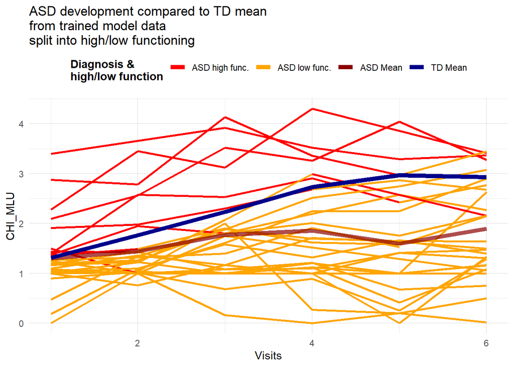

```r
ggplot() +
  geom_line(data = asd_data, aes(x = Visit, y = CHI_MLU, group = Child.ID, color = paste(Diagnosis, functioning, "func.")), size = 1, linetype = "solid") +
  geom_line(data = asd_mean_data, aes(x = Visit, y = Mean_CHI_MLU, color = "ASD Mean"), size = 2, linetype = "solid", alpha = 0.7) +
  geom_line(data = td_mean_data, aes(x = Visit, y = Mean_CHI_MLU, color = "TD Mean"), size = 2) +
  labs(x = "Visits", y = "CHI_MLU", color = "Diagnosis &\nhigh/low function") +
  scale_color_manual(values = c("ASD high func." = "red", "ASD low func." = "orange", "ASD Mean" = "darkred", "TD Mean" = "darkblue")) +
  theme_minimal() +
  theme(legend.position = "top", legend.title = element_text(face = "bold"))+
  ggtitle("ASD development compared to TD mean\nfrom trained model data\nsplit into high/low functioning")
```

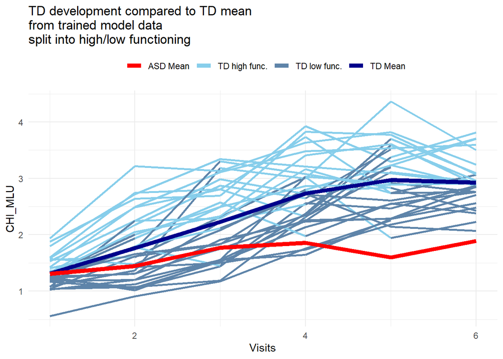

```r
ggplot() +
    geom_line(data = td_data, aes(x = Visit, y = CHI_MLU, group = Child.ID, color = paste(Diagnosis, functioning, "func.")), size = 1, linetype = "solid") +
  geom_line(data = td_mean_data, aes(x = Visit, y = Mean_CHI_MLU, color = "TD Mean"), size = 2) +
  labs(x = "Visits", y = "CHI_MLU", color = "") +
    geom_line(data = asd_mean_data, aes(x = Visit, y = Mean_CHI_MLU, color = "ASD Mean"), size = 2, linetype = "solid") +
  scale_color_manual(values = c("TD high func." = "skyblue", "TD low func." = "#5e84a9", "TD Mean" = "darkblue", "ASD Mean" = "red")) +
  theme_minimal() +
  theme(legend.position = "top", legend.title = element_text(face = "bold"))+
  ggtitle("TD development compared to TD mean\nfrom trained model data\nsplit into high/low functioning")
```

TD children have low within-group variance and tend to develop in a predictable manner. ASD children have high within-group variance, with there being both “high-functioning” and “low-functioning” ASD individuals with very different CHI_MLU development trajectories.

Generally, the first visit CHI_MLU is predictive of future ASD and TD CHI_MLU development, as those who begin below average generally stay below average, and those who begin above average stay that way as well.

## Let’s assume you are a speech therapy clinic. You want to assess whether the kids in your test sample will have a typical (like a TD) development, or they will have a worse one, in which case they should get speech therapy support. What do your predictions tell you about that? Which kids would you provide therapy for? Is the model any good?

Since 1st visit CHI_MLU is rather predictive of the development of the child’s MLU, any ASD child with a value below the TD mean on their first visit may possibly benefit from speech therapy. Since there are also TD children who struggle with MLU, they may also benefit from speech therapy should their MLU be below average on the 1st and consequent visits. That said, they veer off from the mean expected value much less, meaning that ASD children with MLU issues are the ones that (generally) need the speech therapy the most.